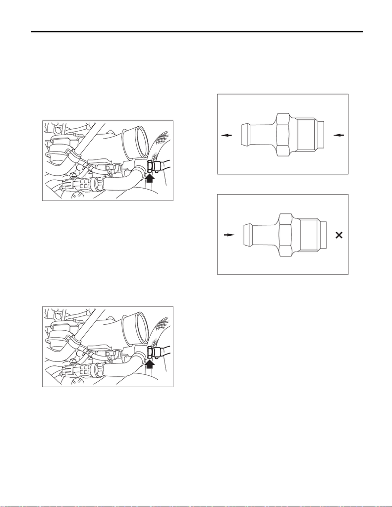

PCV Valve

EMISSION CONTROL (AUX. EMISSION CONTROL DEVICES)

11.PCV Valve

A: REMOVAL

CAUTION:

Do not remove unless the PCV valve is broken.

1) Remove the intercooler. <Ref. to IN(STI)-13,

REMOVAL, Intercooler.>

2) Disconnect the vacuum hose (A) from the PCV

valve and remove the PCV valve from the PCV

connector.

B: INSTALLATION

1) Install the PCV valve to the PCV connector and

connect the vacuum hose (A) to the PCV valve.

NOTE:

Apply liquid gasket to the bolt threads of PCV

valve.

Liquid gasket:

THREE BOND 1324 (Part No. 004403042) or

equivalent

Tightening torque:

22.5 N·m (2.3 kgf-m, 16.6 ft-lb)

2) Install the intercooler. <Ref. to IN(STI)-14, IN-

STALLATION, Intercooler.>

C: INSPECTION

1. PCV VALVE

1) Check that the PCV valve has no deformation,

cracks or other damages.

2) Check that air is discharged from (B) when air is

2. OTHER INSPECTIONS

Check the vacuum hose for cracks, damage or

looseness.

(A)

EC-02746

(A)

EC-02746

EC-02505

(B)

(A)

EC-02506

(A)

(B)